# Report: act_report

## Insights:

### 1. Golden Retriever are the most popular dog on our data set. With almost 150 times, dogs like those ones below seems to be the most famous on twitter, while the second one has less than 100 times which is the Labrador Retriver. That represents how popular this bred is and turn a high interest to this bred makes also increase his value when it turns to selling and buying perspective.

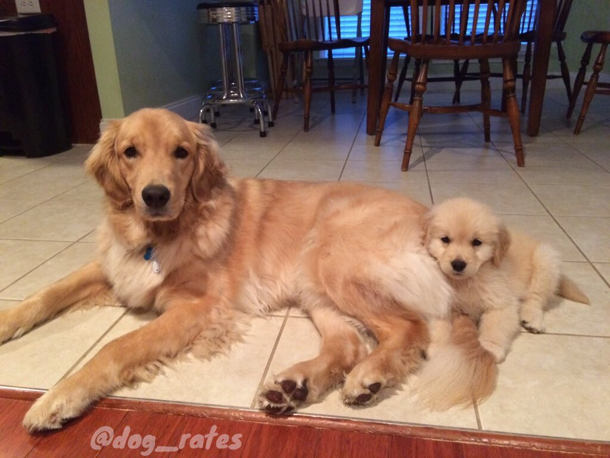

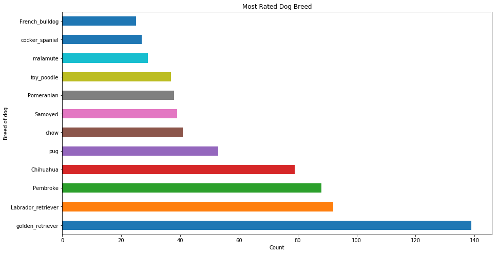

### 2. There is a positive correlation between the favorites and retweet actions. Which just be expected, since probably the most the tweet is retweeted more people it gets, so the chances of increase the numbers of likes get high. The same works on the way around, if a tweet is being favorite, are there more chance to be shared with other users by retweeting. That's why it is important to keep on mind how to monitor the marketing statistics in terms of how far is the tweet going and how much people it gets.

### 3. The rate 1.2 are the most frequent been seen 450 times on our data set.

### 4. The names Copper, Oliver e Charlie repeats 10 times each being the most repeated names followed by Penny, Tucker and Lucy with 9 times each. As the most used names for dog, it is a good alternative to use also on advertising area to catch attention of the public since the name used would be the same name of the most people's dog.

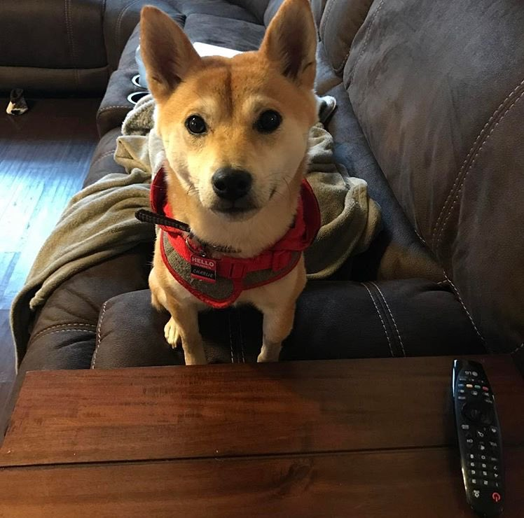

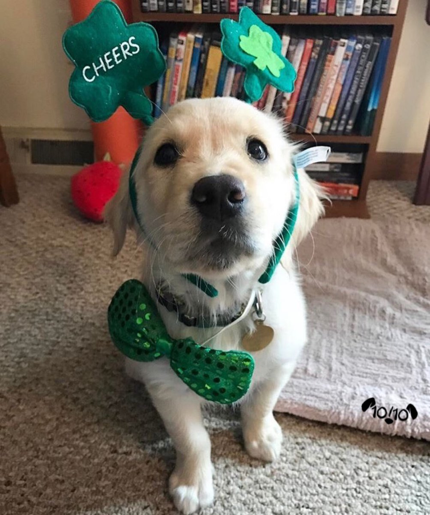

[figure not shown]